# 1. Import Libraries

Before performing any data analysis, we need to import the required Python libraries. These libraries provide functionalities for data manipulation, numerical computation, and visualization.

### Libraries Used

- **Pandas (`pd`)** – Data loading, cleaning, manipulation, and analysis.
- **NumPy (`np`)** – Efficient numerical operations and mathematical computations.
- **Matplotlib (`plt`)** – Data visualization using charts and plots.
- **Pathlib** – Platform-independent file and directory handling.

### Why are libraries important?

Instead of implementing algorithms from scratch, Python libraries provide optimized and well-tested implementations, allowing us to focus on solving machine learning problems efficiently.

### Learning Outcomes

After completing this section, you will be able to:

- Import commonly used Python libraries.
- Understand the purpose of each library.
- Configure display settings for data exploration.

```python
# ==========================================================
# ML Engineering Lab - Data Collection & Data Validation
# Dataset: Olist E-commerce
# ==========================================================

import pandas as pd
import numpy as np
import matplotlib.pyplot as plt

from pathlib import Path

pd.set_option("display.max_columns", None)
pd.set_option("display.max_rows", 10)
```

# 2. Load Dataset

Machine Learning projects begin by collecting and loading data from one or more sources. In this lab, we will use the **Olist Brazilian E-commerce Dataset**, which consists of multiple relational tables such as customers, orders, products, payments, reviews, and sellers.

### Data Collection Pipeline

```
CSV Files
      ↓
Read using Pandas
      ↓
DataFrame
      ↓
Exploration & Validation
```

### Why load data into DataFrames?

A **DataFrame** is a two-dimensional tabular data structure provided by Pandas that enables efficient data manipulation.

If a dataset contains

- **n** rows (records)
- **m** columns (features)

then the dataset can be represented as

$ D \in \mathbb{R}^{n \times m} $

where

- (n) = number of observations
- (m) = number of attributes

### Learning Outcomes

- Load CSV files using Pandas.
- Understand structured tabular datasets.
- Explore relational datasets.

```python
DATA_PATH = "/kaggle/input/datasets/organizations/olistbr/brazilian-ecommerce/"

customers = pd.read_csv(DATA_PATH + "olist_customers_dataset.csv")
orders = pd.read_csv(DATA_PATH + "olist_orders_dataset.csv")
products = pd.read_csv(DATA_PATH + "olist_products_dataset.csv")
payments = pd.read_csv(DATA_PATH + "olist_order_payments_dataset.csv")
```

```python
# TODO

# Load the following datasets

# sellers
# reviews
# order_items

# Write your code below

# Sellers dataset
sellers = pd.read_csv(DATA_PATH + "olist_sellers_dataset.csv")

# Reviews dataset
reviews = pd.read_csv(DATA_PATH + "olist_order_reviews_dataset.csv")

# Order Items dataset
order_items = pd.read_csv(DATA_PATH + "olist_order_items_dataset.csv")

# (Optional) Verify that all datasets have been loaded successfully
print("Customers :", customers.shape)
print("Orders    :", orders.shape)
print("Products  :", products.shape)
print("Payments  :", payments.shape)
print("Sellers   :", sellers.shape)
print("Reviews   :", reviews.shape)
print("OrderItems:", order_items.shape)
```

```
Customers : (99441, 5)
Orders    : (99441, 8)
Products  : (32951, 9)
Payments  : (103886, 5)
Sellers   : (3095, 4)
Reviews   : (99224, 7)
OrderItems: (112650, 7)
```

# 3. First Look at Data

Before cleaning or analyzing a dataset, it is essential to understand its structure. Exploratory Data Analysis (EDA) begins with answering questions such as:

- How many rows are present?
- How many columns exist?
- What are the feature names?
- Which columns contain numerical or categorical data?

### Common Inspection Functions

- `head()`
- `tail()`
- `info()`
- `describe()`

### Why is this important?

Early inspection helps identify

- missing values
- incorrect data types
- unexpected columns
- potential quality issues

### Learning Outcomes

- Inspect datasets.
- Interpret DataFrame information.
- Understand feature distributions.

```python
customers.head()
```

|  | customer_id | customer_unique_id | customer_zip_code_prefix | customer_city | customer_state |
| --- | --- | --- | --- | --- | --- |
| 0 | 06b8999e2fba1a1fbc88172c00ba8bc7 | 861eff4711a542e4b93843c6dd7febb0 | 14409 | franca | SP |
| 1 | 18955e83d337fd6b2def6b18a428ac77 | 290c77bc529b7ac935b93aa66c333dc3 | 9790 | sao bernardo do campo | SP |
| 2 | 4e7b3e00288586ebd08712fdd0374a03 | 060e732b5b29e8181a18229c7b0b2b5e | 1151 | sao paulo | SP |
| 3 | b2b6027bc5c5109e529d4dc6358b12c3 | 259dac757896d24d7702b9acbbff3f3c | 8775 | mogi das cruzes | SP |
| 4 | 4f2d8ab171c80ec8364f7c12e35b23ad | 345ecd01c38d18a9036ed96c73b8d066 | 13056 | campinas | SP |

```python
customers.info()
```

```
<class 'pandas.core.frame.DataFrame'>
RangeIndex: 99441 entries, 0 to 99440
Data columns (total 5 columns):
 #   Column                    Non-Null Count  Dtype
---  ------                    --------------  -----
 0   customer_id               99441 non-null  object
 1   customer_unique_id        99441 non-null  object
 2   customer_zip_code_prefix  99441 non-null  int64
 3   customer_city             99441 non-null  object
 4   customer_state            99441 non-null  object
dtypes: int64(1), object(4)
memory usage: 3.8+ MB
```

```python
customers.describe(include="all")
```

|  | customer_id | customer_unique_id | customer_zip_code_prefix | customer_city | customer_state |
| --- | --- | --- | --- | --- | --- |
| count | 99441 | 99441 | 99441.000000 | 99441 | 99441 |
| unique | 99441 | 96096 | NaN | 4119 | 27 |
| top | 274fa6071e5e17fe303b9748641082c8 | 8d50f5eadf50201ccdcedfb9e2ac8455 | NaN | sao paulo | SP |
| freq | 1 | 17 | NaN | 15540 | 41746 |
| mean | NaN | NaN | 35137.474583 | NaN | NaN |
| ... | ... | ... | ... | ... | ... |
| min | NaN | NaN | 1003.000000 | NaN | NaN |
| 25% | NaN | NaN | 11347.000000 | NaN | NaN |
| 50% | NaN | NaN | 24416.000000 | NaN | NaN |
| 75% | NaN | NaN | 58900.000000 | NaN | NaN |
| max | NaN | NaN | 99990.000000 | NaN | NaN |

11 rows × 5 columns

```python
# TODO

# Display

# first 10 rows of orders
# information of products
# summary statistics of payments

# Display the first 10 rows of the Orders dataset
orders.head(10)

# Display information about the Products dataset
products.info()

# Display summary statistics of the Payments dataset
payments.describe(include="all")
```

```
<class 'pandas.core.frame.DataFrame'>
RangeIndex: 32951 entries, 0 to 32950
Data columns (total 9 columns):
 #   Column                      Non-Null Count  Dtype
---  ------                      --------------  -----
 0   product_id                  32951 non-null  object
 1   product_category_name       32341 non-null  object
 2   product_name_lenght         32341 non-null  float64
 3   product_description_lenght  32341 non-null  float64
 4   product_photos_qty          32341 non-null  float64
 5   product_weight_g            32949 non-null  float64
 6   product_length_cm           32949 non-null  float64
 7   product_height_cm           32949 non-null  float64
 8   product_width_cm            32949 non-null  float64
dtypes: float64(7), object(2)
memory usage: 2.3+ MB
```

|  | order_id | payment_sequential | payment_type | payment_installments | payment_value |
| --- | --- | --- | --- | --- | --- |
| count | 103886 | 103886.000000 | 103886 | 103886.000000 | 103886.00000 |
| unique | 99440 | NaN | 5 | NaN | NaN |
| top | fa65dad1b0e818e3ccc5cb0e39231352 | NaN | credit_card | NaN | NaN |
| freq | 29 | NaN | 76795 | NaN | NaN |
| mean | NaN | 1.092679 | NaN | 2.853349 | 154.10038 |
| ... | ... | ... | ... | ... | ... |
| min | NaN | 1.000000 | NaN | 0.000000 | 0.00000 |
| 25% | NaN | 1.000000 | NaN | 1.000000 | 56.79000 |
| 50% | NaN | 1.000000 | NaN | 1.000000 | 100.00000 |
| 75% | NaN | 1.000000 | NaN | 4.000000 | 171.83750 |
| max | NaN | 29.000000 | NaN | 24.000000 | 13664.08000 |

11 rows × 5 columns

# 4. Dataset Shape

The shape of a dataset represents its dimensions. If a dataset contains

- (n) rows
- (m) columns

then

$ Shape=(n,m) $

Example

```
(99441, 8)
```

means

- 99,441 records
- 8 features

### Why is shape important?

The dimensions of the dataset help estimate

- computational cost
- memory usage
- model complexity

### Learning Outcomes

- Determine dataset dimensions.
- Interpret rows and columns correctly.

```python
print(customers.shape)
```

```
(99441, 5)
```

```python
# TODO

# Print shape of

# orders
# sellers
# reviews
# Shape of Customers dataset
print("Customers:", customers.shape)

# Orders dataset
print("Orders   :", orders.shape)

# Sellers dataset
print("Sellers  :", sellers.shape)

# Reviews dataset
print("Reviews  :", reviews.shape)
```

```
Customers: (99441, 5)
Orders   : (99441, 8)
Sellers  : (3095, 4)
Reviews  : (99224, 7)
```

```python
import numpy as np
import pandas as pd


def inject_olist_impurities(
    df,
    dataset_type="customers",
    noise_ratio=0.05,
    duplicate_ratio=0.02,
    outlier_ratio=0.02,
    seed=42,
):
    """Injects domain errors, missing values, duplicates, and IQR quartile outliers into Olist datasets."""
    np.random.seed(seed)
    df_dirty = df.copy()

    # Helper: Sample random indices
    def get_random_indices(sample_size):
        return np.random.choice(
            df_dirty.index,
            size=min(sample_size, len(df_dirty)),
            replace=False,
        )

    # Helper: Inject extreme upper-bound quartile outliers (Q3 + multiplier * IQR)
    def inject_iqr_outlier(col, sample_size, multiplier=10.0):
        valid_series = df_dirty[col].dropna()
        if valid_series.empty or not pd.api.types.is_numeric_dtype(
            valid_series
        ):
            return
        q1 = valid_series.quantile(0.25)
        q3 = valid_series.quantile(0.75)
        iqr = q3 - q1
        spread = iqr if iqr > 0 else (valid_series.std() or 100.0)

        extreme_val = q3 + (multiplier * spread)
        outlier_idx = get_random_indices(sample_size)
        df_dirty.loc[outlier_idx, col] = extreme_val

    n_total_noise = int(len(df_dirty) * noise_ratio)
    n_outliers = int(len(df_dirty) * outlier_ratio)

    # 1. Dataset-Specific Domain Errors & Quartile Outliers
    if dataset_type == "customers":
        n_per_error = n_total_noise // 3
        df_dirty.loc[get_random_indices(n_per_error), "customer_state"] = (
            np.nan
        )
        df_dirty.loc[
            get_random_indices(n_per_error), "customer_zip_code_prefix"
        ] = np.nan

        city_idx = get_random_indices(n_per_error)
        df_dirty.loc[city_idx, "customer_city"] = (
            df_dirty.loc[city_idx, "customer_city"].astype(str) + "   "
        )

        inject_iqr_outlier(
            "customer_zip_code_prefix", n_outliers, multiplier=10.0
        )

    elif dataset_type == "orders":
        n_per_error = n_total_noise // 2
        df_dirty.loc[
            get_random_indices(n_per_error), "order_delivered_customer_date"
        ] = "2010-01-01 00:00:00"
        df_dirty.loc[
            get_random_indices(n_per_error), "order_status"
        ] = "lost_in_transit"

    elif dataset_type == "products":
        n_per_error = n_total_noise // 2
        df_dirty.loc[get_random_indices(n_per_error), "product_weight_g"] = (
            -500.0
        )
        df_dirty.loc[
            get_random_indices(n_per_error), "product_category_name"
        ] = np.nan

        inject_iqr_outlier("product_weight_g", n_outliers, multiplier=15.0)
        inject_iqr_outlier("product_length_cm", n_outliers, multiplier=15.0)

    elif dataset_type == "payments":
        n_per_error = n_total_noise // 2
        df_dirty.loc[get_random_indices(n_per_error), "payment_value"] = -100.0
        df_dirty.loc[
            get_random_indices(n_per_error), "payment_type"
        ] = "crypto_token"

        inject_iqr_outlier("payment_value", n_outliers, multiplier=15.0)
        inject_iqr_outlier("payment_installments", n_outliers, multiplier=10.0)

    # 2. Inject Duplicate Rows
    if duplicate_ratio > 0:
        n_duplicates = int(len(df_dirty) * duplicate_ratio)
        if n_duplicates > 0:
            dup_indices = get_random_indices(n_duplicates)
            duplicate_rows = df_dirty.loc[dup_indices].copy()
            df_dirty = pd.concat(
                [df_dirty, duplicate_rows], ignore_index=True
            )

    return df_dirty


# Execution Example:
customers = inject_olist_impurities(
    customers, "customers", noise_ratio=0.05, duplicate_ratio=0.02
)
payments = inject_olist_impurities(
    payments, "payments", noise_ratio=0.05, duplicate_ratio=0.02
)
products = inject_olist_impurities(
    products, "products", noise_ratio=0.05, duplicate_ratio=0.02
)
orders = inject_olist_impurities(
    orders, "orders", noise_ratio=0.05, duplicate_ratio=0.02
)
```

```python
# Overwrite your original DataFrames with corrupted data
customers = inject_olist_impurities(
    customers, dataset_type="customers", noise_ratio=0.1
)
orders = inject_olist_impurities(
    orders, dataset_type="orders", noise_ratio=0.1
)
products = inject_olist_impurities(
    products, dataset_type="products", noise_ratio=0.1
)
payments = inject_olist_impurities(
    payments, dataset_type="payments", noise_ratio=0.1
)
```

# 5. Missing Values

Real-world datasets often contain missing or unavailable values. Missing values may occur due to

- sensor failures
- incomplete user input
- transmission errors
- unavailable information

### Mathematical Representation

Suppose

$ D = \{x_1,x_2,\ldots,x_n\} $

A missing value is represented as

$ x_i = \text{NaN} $

The percentage of missing values in a feature is

$ Missing(\%)= \frac{\text{Number of Missing Values}} {\text{Total Number of Records}} \times100 $

### Why does it matter?

Missing values can

- reduce model accuracy
- introduce bias
- prevent algorithms from training

### Learning Outcomes

- Detect missing values.
- Calculate missing percentages.
- Decide appropriate handling techniques.

```python
customers.isnull().sum()
```

[output not shown]

```python
customers.isnull().sum().sort_values(ascending=False)
```

[output not shown]

```python
# TODO

# Find missing values in

# orders
# products
# reviews
# Missing values in Customers dataset
customers.isnull().sum()

# Missing values sorted in descending order
customers.isnull().sum().sort_values(ascending=False)

# Orders dataset
print("Missing Values in Orders")
print(orders.isnull().sum().sort_values(ascending=False))

print("\n" + "="*50 + "\n")

# Products dataset
print("Missing Values in Products")
print(products.isnull().sum().sort_values(ascending=False))

print("\n" + "="*50 + "\n")

# Reviews dataset
print("Missing Values in Reviews")
print(reviews.isnull().sum().sort_values(ascending=False))
```

[output not shown]

```python
missing = customers.isnull().mean()*100

missing.sort_values(ascending=False)
```

```
customer_id                 0.0
customer_unique_id          0.0
customer_zip_code_prefix    0.0
customer_city               0.0
customer_state              0.0
dtype: float64
```

```python
# TODO

# Calculate percentage missing values

# for products dataset
missing_products = products.isnull().mean() * 100

missing_products.sort_values(ascending=False)
```

[output not shown]

```python
customers["customer_city"] = customers["customer_city"].fillna("Unknown")
```

```python
# TODO

# Replace missing review comments

# with "No Review"

reviews["review_comment_message"] = reviews["review_comment_message"].fillna("No Review")
```

# 6. Duplicate Records

Duplicate records represent repeated observations in the dataset. These often arise from

- repeated logging
- synchronization failures
- system retries
- human errors

### Mathematical Definition

Let

$ R_i=(x_1,x_2,\ldots,x_m) $

Two records are duplicates if

$ R_i = R_j $

where

$ i \neq j $

### Why remove duplicates?

Duplicate samples

- distort statistics
- bias machine learning models
- increase storage requirements

### Learning Outcomes

- Detect duplicate records.
- Remove redundant observations.

```python
customers.duplicated().sum()
```

[output not shown]

```python
customers = customers.drop_duplicates()
```

```python
# TODO

# Check duplicates in

# products
# reviews
# sellers
# Products dataset
print("Products :", products.duplicated().sum())

# Reviews dataset
print("Reviews  :", reviews.duplicated().sum())

# Sellers dataset
print("Sellers  :", sellers.duplicated().sum())

# (Optional) Remove duplicate records
products = products.drop_duplicates()
reviews = reviews.drop_duplicates()
sellers = sellers.drop_duplicates()
```

[output not shown]

# 7. Data Types

Every feature in a dataset has an associated data type. Common types include

- Integer
- Float
- Boolean
- String
- Datetime

### Why is datatype validation important?

Incorrect data types can lead to

- computation errors
- visualization issues
- incorrect model inputs

Example

```
"100"
```

is a string,

whereas

```
100
```

is an integer.

### Learning Outcomes

- Identify feature data types.
- Convert incorrect data types.
- Parse datetime columns.

```python
orders.dtypes
```

[output not shown]

```python
orders["order_purchase_timestamp"] = pd.to_datetime(
    orders["order_purchase_timestamp"]
)
```

```python
# TODO

# Convert all timestamp columns

# into datetime
# Orders dataset timestamps
orders["order_approved_at"] = pd.to_datetime(
    orders["order_approved_at"]
)

orders["order_delivered_carrier_date"] = pd.to_datetime(
    orders["order_delivered_carrier_date"]
)

orders["order_delivered_customer_date"] = pd.to_datetime(
    orders["order_delivered_customer_date"]
)

orders["order_estimated_delivery_date"] = pd.to_datetime(
    orders["order_estimated_delivery_date"]
)

# Reviews dataset timestamp
reviews["review_creation_date"] = pd.to_datetime(
    reviews["review_creation_date"]
)

reviews["review_answer_timestamp"] = pd.to_datetime(
    reviews["review_answer_timestamp"]
)

# Order Items dataset timestamp
order_items["shipping_limit_date"] = pd.to_datetime(
    order_items["shipping_limit_date"]
)
```

```python
payments[payments["payment_value"] < 0]
```

[output not shown]

```python
# TODO

# Find

# invalid freight values

# invalid payment values
# Invalid freight values (negative freight charges)
order_items[order_items["freight_value"] < 0]

# Invalid payment values (negative payment amounts)
payments[payments["payment_value"] < 0]
```

[output not shown]

```python
orders["order_status"].unique()
```

[output not shown]

```python
# TODO

# Find unique values

# in customer_state
customers["customer_state"].nunique()
```

```
27
```

```python
orders["order_status"].value_counts()
```

[output not shown]

```python
# TODO

# Top 10 customer cities
top_cities = customers["customer_city"].value_counts().head(10)
print(top_cities)
```

```
customer_city
sao paulo                15540
rio de janeiro            6882
belo horizonte            2773
brasilia                  2131
curitiba                  1521
campinas                  1444
porto alegre              1379
salvador                  1245
guarulhos                 1189
sao bernardo do campo      938
Name: count, dtype: int64
```

# 8. Outlier Detection

Outliers are observations that differ significantly from the majority of the data.

### Interquartile Range (IQR)

$ IQR=Q_3-Q_1 $

where

- (Q_1) = First Quartile
- (Q_3) = Third Quartile

A value is considered an outlier if

$ x<Q_1-1.5(IQR) $

or

$ x>Q_3+1.5(IQR) $

### Why detect outliers?

Outliers can

- skew averages
- affect regression models
- reduce prediction performance

### Learning Outcomes

- Visualize outliers.
- Compute IQR.
- Identify abnormal observations.

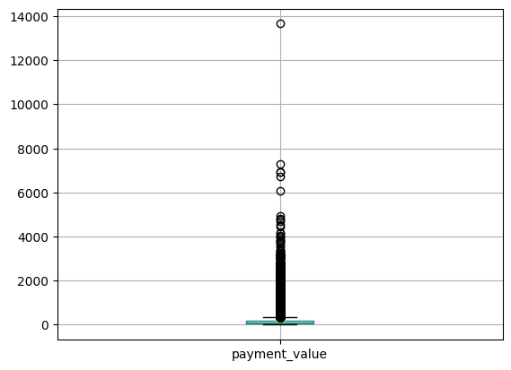

```python
payments.boxplot(column="payment_value")
plt.show()
```

```python
Q1 = payments["payment_value"].quantile(0.25)
Q3 = payments["payment_value"].quantile(0.75)

IQR = Q3 - Q1

outliers = payments[
    (payments["payment_value"] < Q1 - 1.5*IQR) |
    (payments["payment_value"] > Q3 + 1.5*IQR)
]

outliers.head()
```

|  | order_id | payment_sequential | payment_type | payment_installments | payment_value |
| --- | --- | --- | --- | --- | --- |
| 23 | 4d680edbaa7d3d9bed69532957368a03 | 1 | credit_card | 10 | 353.09 |
| 26 | d0a945f85ba1074b60aac97ade7e240e | 1 | credit_card | 2 | 541.00 |
| 52 | 2e2c60b99754ae1e4d8b18846cfec9f2 | 1 | credit_card | 4 | 542.66 |
| 54 | 95442deb81a5d91c97c0df96b431634a | 1 | boleto | 1 | 368.98 |
| 61 | 3ab4eea6776259ae8dfbabaeffece352 | 1 | credit_card | 8 | 387.80 |

```python
# TODO

# Detect outliers

# in freight_value
Q1 = order_items["freight_value"].quantile(0.25)
Q3 = order_items["freight_value"].quantile(0.75)

IQR = Q3 - Q1

freight_outliers = order_items[
    (order_items["freight_value"] < Q1 - 1.5 * IQR) |
    (order_items["freight_value"] > Q3 + 1.5 * IQR)
]

# Display the first few outlier records
freight_outliers.head()
```

|  | order_id | order_item_id | product_id | seller_id | shipping_limit_date | price | freight_value |
| --- | --- | --- | --- | --- | --- | --- | --- |
| 7 | 000576fe39319847cbb9d288c5617fa6 | 1 | 557d850972a7d6f792fd18ae1400d9b6 | 5996cddab893a4652a15592fb58ab8db | 2018-07-10 12:30:45 | 810.00 | 70.75 |
| 22 | 000f25f4d72195062c040b12dce9a18a | 1 | 1c05e0964302b6cf68ca0d15f326c6ba | 7c67e1448b00f6e969d365cea6b010ab | 2018-03-21 11:10:11 | 119.99 | 44.40 |
| 39 | 0017afd5076e074a48f1f1a4c7bac9c5 | 1 | fe59a1e006df3ac42bf0ceb876d70969 | 25c5c91f63607446a97b143d2d535d31 | 2017-04-24 22:25:19 | 809.10 | 44.29 |
| 59 | 00254baeb6c932b0a8aeead91fbd02b5 | 1 | 18901878788fec7ddc55e64d1ace8187 | e8b4225284fbb02d16f200513f1f395d | 2018-05-14 22:14:46 | 149.90 | 43.11 |
| 73 | 002b430ff89b3a24c31a1170acbbedea | 1 | cc47c0863559499f01b4cad750929d10 | 7a67c85e85bb2ce8582c35f2203ad736 | 2017-06-26 22:10:14 | 199.99 | 65.56 |

# 9. Schema Validation

A schema defines the expected structure of a dataset. It specifies

- feature names
- data types
- constraints

### Schema Definition

If

$ S=\{c_1,c_2,\ldots,c_m\} $

is the expected schema,

then

$ Columns(D)=S $

must hold for a valid dataset.

### Why is schema validation important?

Schema validation prevents

- missing columns
- incorrect column names
- incompatible data types

### Learning Outcomes

- Compare expected and actual schemas.
- Detect schema violations.

```python
expected_columns = [
    "order_id",
    "customer_id",
    "order_status",
    "order_purchase_timestamp"
]
```

```python
missing_columns = set(expected_columns) - set(orders.columns)

missing_columns
```

```
set()
```

```python
# TODO

# Check whether

# products dataset

# contains all expected columns
expected_columns = [
    "order_id",
    "customer_id",
    "order_status",
    "order_purchase_timestamp"
]

missing_columns = set(expected_columns) - set(orders.columns)

print("Missing columns in Orders:", missing_columns)


expected_product_columns = [
    "product_id",
    "product_category_name",
    "product_name_lenght",
    "product_description_lenght",
    "product_photos_qty",
    "product_weight_g",
    "product_length_cm",
    "product_height_cm",
    "product_width_cm"
]

missing_product_columns = set(expected_product_columns) - set(products.columns)

print("Missing columns in Products:", missing_product_columns)
```

```
Missing columns in Orders: set()
Missing columns in Products: set()
```

# 10. Cross-field Validation

Cross-field validation ensures logical consistency between multiple columns. Example:

For an e-commerce order, $ Purchase\ Date \leq Delivery\ Date $, must always hold.

If, $ Delivery\ Date < Purchase\ Date $, the record is invalid.

### Why is this important?

Cross-field validation identifies

- impossible events
- timestamp inconsistencies
- business rule violations

### Learning Outcomes

- Validate relationships across columns.
- Detect logically inconsistent records.

```python
orders["order_purchase_timestamp"] = pd.to_datetime(
    orders["order_purchase_timestamp"]
)

orders["order_delivered_customer_date"] = pd.to_datetime(
    orders["order_delivered_customer_date"]
)

invalid = orders[
    orders["order_delivered_customer_date"] <
    orders["order_purchase_timestamp"]
]

invalid.head()
```

|  | order_id | customer_id | order_status | order_purchase_timestamp | order_approved_at | order_delivered_carrier_date | order_delivered_customer_date | order_estimated_delivery_date |
| --- | --- | --- | --- | --- | --- | --- | --- | --- |

```python
# TODO

# Find orders

# where estimated delivery date

# is before purchase date

orders["order_estimated_delivery_date"] = pd.to_datetime(
    orders["order_estimated_delivery_date"]
)

invalid_estimated_delivery = orders[
    orders["order_estimated_delivery_date"] <
    orders["order_purchase_timestamp"]
]

invalid_estimated_delivery.head()
```

|  | order_id | customer_id | order_status | order_purchase_timestamp | order_approved_at | order_delivered_carrier_date | order_delivered_customer_date | order_estimated_delivery_date |
| --- | --- | --- | --- | --- | --- | --- | --- | --- |

# 11. Data Summary Report

A validation report summarizes the overall quality of a dataset. Typical metrics include

- Number of rows
- Number of columns
- Missing values
- Duplicate records
- Data types
- Unique values
- Outliers

### Why generate a report?

A summary report provides a quick overview of data quality before machine learning begins.

### Learning Outcomes

- Build automated validation reports.
- Assess dataset readiness for ML pipelines.

```python
summary = pd.DataFrame({
    "Missing Values": orders.isnull().sum(),
    "Data Type": orders.dtypes,
    "Unique Values": orders.nunique()
})

summary
```

[output not shown]

# 12. Lab Exercise

```python
# ==========================================================
# 🏆 Lab Exercise: Data Collection & Data Validation
# ==========================================================
#
# Objective
# ---------
# Apply the concepts learned in this lab to perform a complete
# data validation workflow on one of the Olist e-commerce datasets.
#
# Choose dataset: reviews
```

```python
# ✅ Task 1: Load the selected dataset.
#
# ✅ Task 2: Perform initial exploration.
#    - Display the first few records.
#    - Check dataset shape.
#    - View column names and data types.
#
# ✅ Task 3: Identify missing values.
#    - Count missing values.
#    - Calculate the percentage of missing values.
#
# ✅ Task 4: Detect and remove duplicate records.
#
# ✅ Task 5: Validate the dataset.
#    - Verify data types.
#    - Check for invalid or inconsistent values.
#
# ✅ Task 6: Detect outliers.
#    - Use the IQR method.
#    - Visualize using a boxplot.
#
# ✅ Task 7: Generate a Data Quality Report.
#    Include:
#      • Number of rows
#      • Number of columns
#      • Missing values
#      • Duplicate records
#      • Unique values
#      • Data types
#      • Number of detected outliers
#
# ✅ Task 8: Save the cleaned dataset as a new CSV file.
```

```
==================================================
FIRST 5 RECORDS
==================================================
                          review_id                          order_id  \
0  7bc2406110b926393aa56f80a40eba40  73fc7af87114b39712e6da79b0a377eb
1  80e641a11e56f04c1ad469d5645fdfde  a548910a1c6147796b98fdf73dbeba33
2  228ce5500dc1d8e020d8d1322874b6f0  f9e4b658b201a9f2ecdecbb34bed034b
3  e64fb393e7b32834bb789ff8bb30750e  658677c97b385a9be170737859d3511b
4  f7c4243c7fe1938f181bec41a392bdeb  8e6bfb81e283fa7e4f11123a3fb894f1

   review_score review_comment_title  \
0             4                  NaN
1             5                  NaN
2             5                  NaN
3             5                  NaN
4             5                  NaN

                              review_comment_message review_creation_date  \
0                                                NaN  2018-01-18 00:00:00
1                                                NaN  2018-03-10 00:00:00
2                                                NaN  2018-02-17 00:00:00
3              Recebi bem antes do prazo estipulado.  2017-04-21 00:00:00
4  Parabéns lojas lannister adorei comprar pela I...  2018-03-01 00:00:00

  review_answer_timestamp
0     2018-01-18 21:46:59
1     2018-03-11 03:05:13
2     2018-02-18 14:36:24
3     2017-04-21 22:02:06
4     2018-03-02 10:26:53

Dataset Shape:
(99224, 7)

Column Names:
['review_id', 'order_id', 'review_score', 'review_comment_title', 'review_comment_message', 'review_creation_date', 'review_answer_timestamp']

Data Types:
review_id                  object
order_id                   object
```

[output cut: 41 more lines]

```
review_id                  object
order_id                   object
review_score                int64
review_comment_title       object
review_comment_message     object
review_creation_date       object
review_answer_timestamp    object
dtype: object

Invalid Review Scores: 0
Invalid Date Records: 0

==================================================
OUTLIER DETECTION
==================================================
```

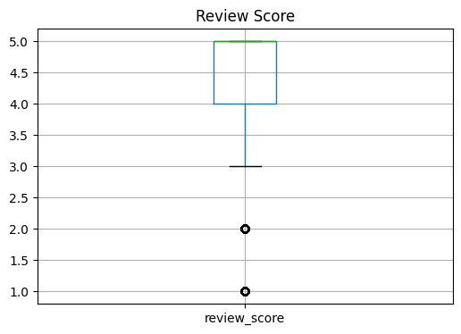

```
Number of Outliers: 14575

==================================================
DATA QUALITY REPORT
==================================================
Rows: 99224
Columns: 7

Missing Values:
145903

Duplicate Records:
0

Unique Values:
review_id                  98410
order_id                   98673
review_score                   5
review_comment_title        4527
review_comment_message     36159
review_creation_date         636
review_answer_timestamp    98248
dtype: int64

Data Types:
review_id                          object
order_id                           object
review_score                        int64
review_comment_title               object
review_comment_message             object
review_creation_date       datetime64[ns]
review_answer_timestamp    datetime64[ns]
dtype: object

Invalid Review Scores: 0
Invalid Date Records: 0
Outliers (Review Score): 14575

✅ Cleaned dataset saved as 'olist_reviews_cleaned.csv'
```

```python
# ==========================================================
# 🏆 Lab Exercise SOLUTION
# Dataset Selected: Reviews
# ==========================================================

import pandas as pd
import matplotlib.pyplot as plt

# ==========================================================
# Task 1: Load the Dataset
# ==========================================================

DATA_PATH = "/kaggle/input/datasets/organizations/olistbr/brazilian-ecommerce/"

reviews = pd.read_csv(DATA_PATH + "olist_order_reviews_dataset.csv")

# ==========================================================
# Task 2: Initial Exploration
# ==========================================================

print("=" * 50)
print("FIRST 5 RECORDS")
print("=" * 50)
print(reviews.head())

print("\nDataset Shape:")
print(reviews.shape)

print("\nColumn Names:")
print(reviews.columns.tolist())

print("\nData Types:")
print(reviews.dtypes)

# ==========================================================
# Task 3: Missing Values
# ==========================================================

print("\n" + "=" * 50)
print("MISSING VALUES")
print("=" * 50)

missing_count = reviews.isnull().sum()
missing_percentage = reviews.isnull().mean() * 100

print("Missing Value Count:")
print(missing_count)

print("\nMissing Percentage:")
print(missing_percentage.sort_values(ascending=False))

# ==========================================================
# Task 4: Duplicate Records
# ==========================================================

print("\n" + "=" * 50)
print("DUPLICATE RECORDS")
print("=" * 50)

duplicates = reviews.duplicated().sum()
print("Duplicate Records:", duplicates)

reviews = reviews.drop_duplicates()

print("Shape After Removing Duplicates:", reviews.shape)

# ==========================================================
# Task 5: Dataset Validation
# ==========================================================

print("\n" + "=" * 50)
print("DATA VALIDATION")
print("=" * 50)

print("\nData Types:")
print(reviews.dtypes)

# Convert timestamps
reviews["review_creation_date"] = pd.to_datetime(
    reviews["review_creation_date"]
)

reviews["review_answer_timestamp"] = pd.to_datetime(
    reviews["review_answer_timestamp"]
)

# Check invalid review scores
invalid_scores = reviews[
    (reviews["review_score"] < 1) |
    (reviews["review_score"] > 5)
]

print("\nInvalid Review Scores:", len(invalid_scores))

# Check invalid timestamps
invalid_dates = reviews[
    reviews["review_answer_timestamp"] <
    reviews["review_creation_date"]
]

print("Invalid Date Records:", len(invalid_dates))

# ==========================================================
# Task 6: Outlier Detection (IQR Method)
# ==========================================================

print("\n" + "=" * 50)
print("OUTLIER DETECTION")
print("=" * 50)

plt.figure(figsize=(6,4))
reviews.boxplot(column="review_score")
plt.title("Review Score")
plt.show()

Q1 = reviews["review_score"].quantile(0.25)
Q3 = reviews["review_score"].quantile(0.75)

IQR = Q3 - Q1

outliers = reviews[
    (reviews["review_score"] < Q1 - 1.5 * IQR) |
    (reviews["review_score"] > Q3 + 1.5 * IQR)
]

print("Number of Outliers:", len(outliers))

# ==========================================================
# Task 7: Data Quality Report
# ==========================================================

print("\n" + "=" * 50)
print("DATA QUALITY REPORT")
print("=" * 50)

print("Rows:", reviews.shape[0])
print("Columns:", reviews.shape[1])

print("\nMissing Values:")
print(reviews.isnull().sum().sum())

print("\nDuplicate Records:")
print(reviews.duplicated().sum())

print("\nUnique Values:")
print(reviews.nunique())

print("\nData Types:")
print(reviews.dtypes)

print("\nInvalid Review Scores:", len(invalid_scores))
print("Invalid Date Records:", len(invalid_dates))
print("Outliers (Review Score):", len(outliers))

# ==========================================================
# Task 8: Save the Cleaned Dataset
# ==========================================================

reviews.to_csv("olist_reviews_cleaned.csv", index=False)

print("\n✅ Cleaned dataset saved as 'olist_reviews_cleaned.csv'")
```

```python
# Deliverables
# ------------
# • Cleaned dataset (.csv)
# • Data Quality Report
# • Well-documented notebook with explanations
```

# 13. Final Challenge

```python
# Create a reusable function:
#
#     validate_dataset(df)
#
# that automatically performs all validation checks and
# returns a comprehensive summary report for any dataset.
```

```python
# ==========================================================
# Reusable Dataset Validation Function
# ==========================================================

import pandas as pd

def validate_dataset(df):
    """
    Performs a complete data validation workflow on any Pandas DataFrame.

    Parameters
    ----------
    df : pandas.DataFrame

    Returns
    -------
    report : dict
        Dictionary containing the data quality summary.
    """

    report = {}

    # ------------------------------------------------------
    # Basic Information
    # ------------------------------------------------------

    report["Rows"] = df.shape[0]
    report["Columns"] = df.shape[1]

    # ------------------------------------------------------
    # Missing Values
    # ------------------------------------------------------

    missing_count = df.isnull().sum()
    missing_percentage = (df.isnull().mean() * 100).round(2)

    report["Missing Values"] = missing_count
    report["Missing Percentage"] = missing_percentage

    # ------------------------------------------------------
    # Duplicate Records
    # ------------------------------------------------------

    report["Duplicate Records"] = df.duplicated().sum()

    # ------------------------------------------------------
    # Data Types
    # ------------------------------------------------------

    report["Data Types"] = df.dtypes

    # ------------------------------------------------------
    # Unique Values
    # ------------------------------------------------------

    report["Unique Values"] = df.nunique()

    # ------------------------------------------------------
    # Invalid Numeric Values
    # (Negative values)
    # ------------------------------------------------------

    invalid_values = {}

    numeric_columns = df.select_dtypes(include=["int64", "float64"]).columns

    for col in numeric_columns:
        invalid_values[col] = (df[col] < 0).sum()

    report["Invalid Numeric Values"] = invalid_values

    # ------------------------------------------------------
    # Outlier Detection (IQR)
    # ------------------------------------------------------

    outliers = {}

    for col in numeric_columns:

        Q1 = df[col].quantile(0.25)
        Q3 = df[col].quantile(0.75)

        IQR = Q3 - Q1

        lower = Q1 - 1.5 * IQR
        upper = Q3 + 1.5 * IQR

        count = ((df[col] < lower) | (df[col] > upper)).sum()

        outliers[col] = count

    report["Outliers"] = outliers

    return report


# ==========================================================
# Example Usage
# ==========================================================

report = validate_dataset(products)

print("=" * 60)
print("DATA QUALITY REPORT")
print("=" * 60)

print(f"Rows: {report['Rows']}")
print(f"Columns: {report['Columns']}")
print(f"Duplicate Records: {report['Duplicate Records']}")

print("\nMissing Values")
print(report["Missing Values"])

print("\nMissing Percentage (%)")
print(report["Missing Percentage"])

print("\nData Types")
print(report["Data Types"])

print("\nUnique Values")
print(report["Unique Values"])

print("\nInvalid Numeric Values")
print(report["Invalid Numeric Values"])

print("\nOutliers")
print(report["Outliers"])
```

[output not shown]